# Assignment 2 - Almond Yield Function

Becca Reynolds, Madeline Oliver, Simone Albuquerque, Siya Qiu

4/7/2021

## California almond yield anomoly (1989-2010)

The response of yields to temperature and precipitation changes was described for each crop using statistical models developed from1980–2003 records of state-wide yield and monthly average temperatures (minimum and maximum) and rainfall variations (Lobell et al., in press).This function utilizes Lobell et al.’s statistical model to transform monthly averages of minimum temperatures(Tn) and precipitation (P) into a prediction of annual almond yield. The output of the almond_yield_model() function is a dataframe of almond yields and the date. Additionally, the coefficients affected by temperature and those that are affected by precipitation are output as columns in the dataframe to give more information on what climatic occurences are greatly affecting almond yield. Yield tends to decline as temperatures increase in February, based on Lobell et al.’s findings with minimum temperatures below 4 degrees celsius yielding more almonds and minimum temperatures above 4 degrees celsius yielding less. The graphs below illustrate whether the findings based on alternate data using the almond_yield_model() functionare consistent Lobell et al.’s findings.

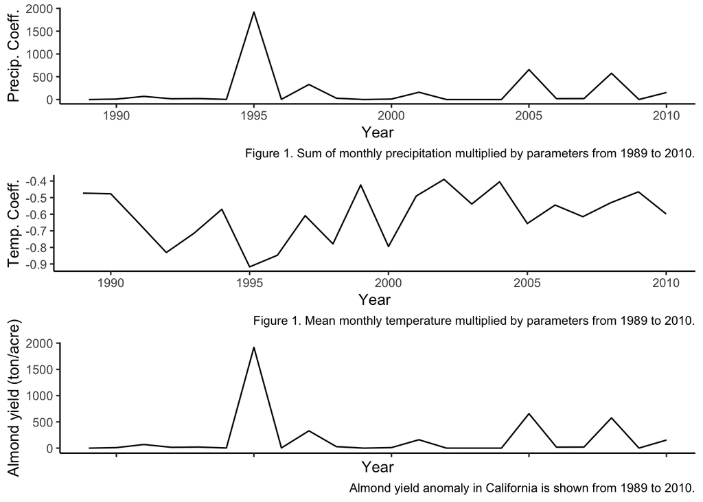

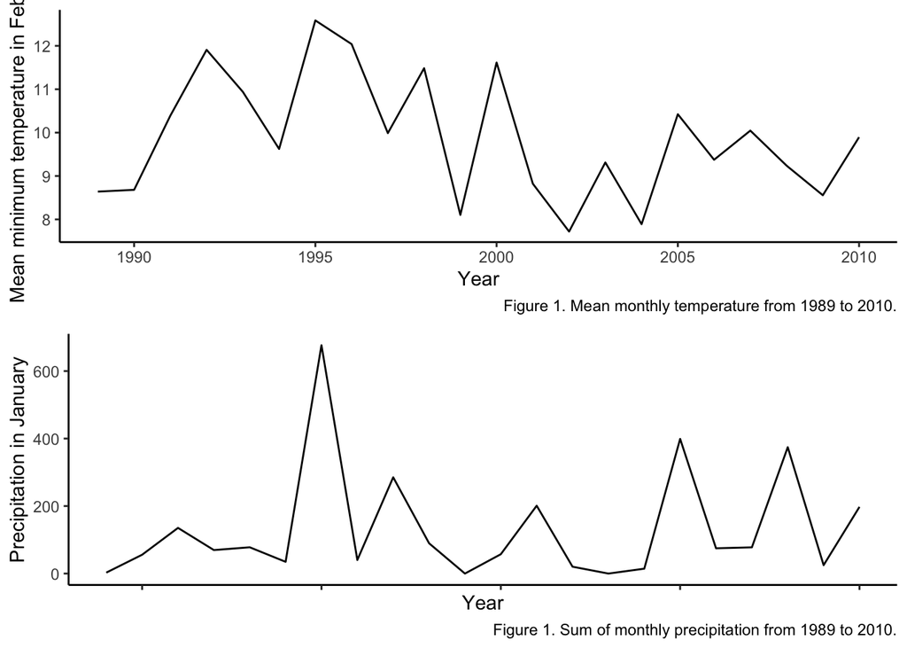

Mean minimum temperatures never fall below 4 degrees celsius. Since there is not a variation in temperature, beyond the threshold for higher yields as Lobell et. al. observed, precipitation becomes the a significant determinant of variation in almond yields between 1989 and 2010.